# Unit B: Point Estimate

Instructor: Dr. Md Mutasim Billah

# Statistical Inference

## Models and Parameters

- Statistical models describe populations using probability distributions, represented by probability density functions (PDFs) or probability mass functions (PMFs).
- These distributions usually depend on unknown **parameters**.
  - We use $\theta$ as a general symbol for a parameter.
- Examples:
  - The lifetime of a string of Christmas lights follows an exponential distribution, $\operatorname{Exp}(\theta)$.
  - The average amount in 63 poured drinks is approximately normally distributed with mean $\theta$.
  - The number of people with a disease among $n$ independently sampled people follows $\operatorname{Binomial}(n,\theta)$, where $\theta$ is the population prevalence.
- In practice, the value of $\theta$ is unknown.

## Learning from Data

- Our observed data come from a **random sample** of the population.
- Given the observed data, what can we say about $\theta$?
- We model the sample as random variables $X_1,\ldots,X_n$ and use their observed values to draw conclusions about the unknown population parameter.
- **Example:** Five strings of Christmas lights from the same manufacturer lasted

  $$21,\quad 103,\quad 76,\quad 88,\quad 96
  \quad \text{days}.$$
- Assuming that their lifetimes are independent and follow $\operatorname{Exp}(\theta)$, with $\theta$ representing the failure rate, what do these data tell us about $\theta$?

## Example: Estimating Disease Prevalence

Suppose we take a random sample of **100 people** and test each person for a disease. **Three people** have the disease.

Let $\theta$ denote the prevalence of the disease in the population.

The sample proportion gives the estimate (point estimate)

$$\widehat{\theta}
=
\frac{3}{100}
=
0.03
=
3\%.$$

- How certain are we about this estimate?
- Can we be confident that the population prevalence is greater than **2%**?

## Estimation and Decisions

- **Estimation:** Estimate an unknown population parameter.
  - For example, we estimated disease prevalence as $\widehat{\theta}=3\%$.
  - A **point estimate** provides a single numerical value.
  - An **interval estimate** provides a range of plausible values.
- **Making decisions:** Use hypothesis testing and decision theory.
  - Suppose the state will launch a costly public health campaign if the disease affects **2% or more** of the population.
  - Do the data provide sufficient evidence that $\theta$ is greater than $0.02$?

## Population and Sample

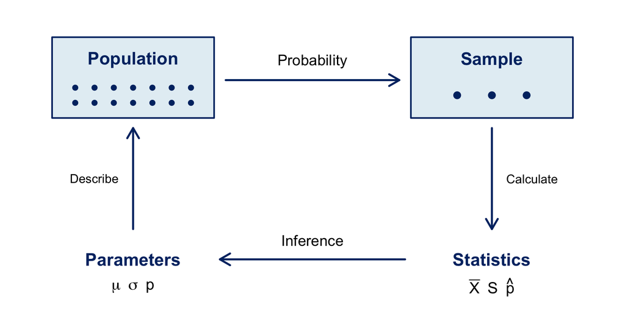

- **Probability:** Start with a population model and study possible sample outcomes.
- **Inference:** Start with sample data and learn about unknown population parameters.

# Point Estimation

## Introduction

- We often want to estimate an unknown **population parameter** using the results of a **random sample**.
- Examples of population parameters include:
  - Population mean: $\mu$
  - Population proportion: $p$
  - Population standard deviation: $\sigma$
- A statistic calculated from the sample provides an estimate of the corresponding population parameter.

## Point Estimation

- Let $\theta$ denote an unknown population parameter.
- A **point estimator** of $\theta$ is a statistic used to estimate $\theta$.
- A **point estimate** is the observed numerical value of that statistic for a particular sample.
- The point estimate is regarded as a plausible value of the unknown parameter.

## Parameters, Point Estimators, and Point Estimates

| Population parameter | Point estimator | Observed point estimate |
| --- | --- | --- |
| Mean $\mu$ | $\overline{X}$ | $\overline{x}$ |
| Proportion $p$ | $\widehat{p}=X/n$ | $\widehat{p}=x/n$ |
| Standard deviation $\sigma$ | $S$ | $s$ |

- An **estimator** is a random variable because its value depends on the random sample.
- An **estimate** is the numerical value obtained after observing the sample.
- For the sample proportion, $X$ is the random number of successes and $x$ is its observed value. The notation $\widehat{p}$ is commonly used for both the estimator and its observed value.

## Example: Estimating a Population Proportion

A random sample of **500 Clevelanders** is taken, and **110** say that they like lakes.

- **Parameter:** $p$, the proportion of all people in Cleveland who like lakes.
- **Point estimator:**

  $$\widehat{p}=\frac{X}{n}.$$
- **Point estimate:**

  $$\widehat{p}=\frac{110}{500}=0.22.$$
- We estimate that **22%** of people in Cleveland like lakes.

```r
x <- 110
n <- 500

p_hat <- x / n
p_hat
## [1] 0.22
```

# Properties of Point Estimators

## Unbiased Estimators

An estimator $\widehat{\theta}$ is an **unbiased estimator** of $\theta$ if

$$E(\widehat{\theta})=\theta.$$

The **bias** of an estimator is

$$\operatorname{Bias}(\widehat{\theta})
=
E(\widehat{\theta})-\theta.$$

An unbiased estimator has bias equal to zero.

**Class discussion:** For an i.i.d. random sample with the relevant finite moments:

1. Is $\overline{X}$ an unbiased estimator of $\mu$?
2. Is $\widehat{p}$ an unbiased estimator of $p$?
3. Is $S^2$ an unbiased estimator of $\sigma^2$, when $S^2$ uses the denominator $n-1$?

## Unbiased Estimation of the Mean and Variance

### Assumptions and Definitions

Let $X_1,\ldots,X_n$ be independent and identically distributed random variables, with $n\ge 2$, such that

$$E(X_i)=\mu,
\qquad
\operatorname{Var}(X_i)=\sigma^2<\infty.$$

Define the **sample mean** and **sample variance** by

$$\overline{X}=\frac{1}{n}\sum_{i=1}^{n}X_i,$$

$$S^2=\frac{1}{n-1}\sum_{i=1}^{n}(X_i-\overline{X})^2.$$

We will show that

$$\boxed{E(\overline{X})=\mu
\qquad\text{and}\qquad
E(S^2)=\sigma^2.}$$

**Normality is not required for these results.**

### Why Do We Divide by n − 1 Instead of n?

Suppose we instead define

$$\widetilde{S}^{\,2}
=
\frac{1}{n}\sum_{i=1}^{n}(X_i-\overline{X})^2.$$

Since $\widetilde{S}^{\,2}=\frac{n-1}{n}S^2$,

$$E(\widetilde{S}^{\,2})
=
\frac{n-1}{n}E(S^2)
=
\frac{n-1}{n}\sigma^2.$$

Its bias is

$$\begin{aligned}
\operatorname{Bias}(\widetilde{S}^{\,2})
&=E(\widetilde{S}^{\,2})-\sigma^2\\[4pt]
&=-\frac{\sigma^2}{n}.
\end{aligned}$$

For $\sigma^2>0$, dividing by $n$ **underestimates the population variance on average**. Dividing by $n-1$ removes this bias.

### Degrees of Freedom

- Once $\bar{X}$ is calculated, the deviations

$$X_1-\bar{X},\ldots,X_n-\bar{X}$$

are not all free to vary independently.

- This is because they must satisfy

$$\boxed{
\sum_{i=1}^{n}(X_i-\bar{X})=0
}$$

- Therefore, if we know any $n-1$ of the deviations, the last one is automatically determined.
- We say there are

$$\boxed{n-1\text{ degrees of freedom}}$$

- In other words, only $n-1$ of the deviations are free to vary independently.

### Notes

- **Unbiasedness is a repeated-sampling property.** It does not mean that every observed sample variance equals $\sigma^2$.
- Across repeated random samples, the sampling distribution of $S^2$ has mean $\sigma^2$.

## Standard Error

The **standard error** of an estimator is the standard deviation of its sampling distribution:

$$\sigma_{\widehat{\theta}}
=
\sqrt{\operatorname{Var}(\widehat{\theta})}.$$

- The standard error describes how much the estimator varies from sample to sample.
- If the standard error contains unknown population parameters, we can replace them with estimates.
- The resulting quantity is called the **estimated standard error**.
- Following the notation in these slides, we denote the estimated standard error by $\widehat{\operatorname{SE}}(\widehat{\theta})$.

## Reporting a Point Estimate and Its Standard Error

The standard error, or its estimate, should be reported with the point estimate to indicate its precision.

**Example:** Estimate a population mean $\mu$ when $\sigma$ is unknown.

For an i.i.d. sample:

- The point estimate of $\mu$ is $\overline{x}$.
- The standard error of the sample mean is

  $$\sigma_{\overline{X}}=\frac{\sigma}{\sqrt{n}}.$$
- When $\sigma$ is unknown, estimate it using $s$:

  $$\widehat{\operatorname{SE}}(\overline{X})
  =
  \frac{s}{\sqrt{n}}.$$

Report $\overline{x}$ together with its estimated standard error $s/\sqrt{n}$.

## Goal for Point Estimators

- We want an estimator with **small bias** and **small spread**.
- An unbiased estimator has bias equal to **zero**.
- Spread describes how much the estimator varies across repeated samples.
- For the sample mean, increasing the sample size reduces its standard error:

  $$\sigma_{\overline{X}}=\frac{\sigma}{\sqrt{n}}.$$
- If the estimate is not sufficiently precise, increasing the sample size can improve precision.

# Mean Squared Error

## Mean Squared Error

The **mean squared error** of $\widehat{\theta}$ as an estimator of $\theta$ is

$$\operatorname{MSE}(\widehat{\theta})
=
E\left[(\widehat{\theta}-\theta)^2\right].$$

It can be written as

$$\boxed{
\operatorname{MSE}(\widehat{\theta})
=
\operatorname{Var}(\widehat{\theta})
+
\left[\operatorname{Bias}(\widehat{\theta})\right]^2
}.$$
where,

$$\operatorname{Bias}(\widehat{\theta})
=
E(\widehat{\theta})-\theta.$$

**Example:** For an i.i.d. sample with mean $\mu$ and finite variance $\sigma^2$, $\overline{X}$ is unbiased for $\mu$. Therefore,

$$\operatorname{MSE}(\overline{X})
=
\operatorname{Var}(\overline{X})
=
\frac{\sigma^2}{n}.$$

## Comparing Estimators Using MSE

- We want an estimator with **small bias** and **small spread**.
- MSE measures overall estimation error by combining **variance** and **squared bias**.
- For an unbiased estimator,

  $$\operatorname{MSE}(\widehat{\theta})
  =
  \operatorname{Var}(\widehat{\theta}).$$
- If two estimators are both unbiased for the same parameter, the estimator with the **smaller MSE** also has the **smaller variance**.
- Under the MSE criterion, we prefer the estimator with the smaller MSE.